# FGCZ tabset layout example

**Overview**

[figure not shown]

Visual abstract of the FGCZ reporting workflow. Compact assay inputs feed an analysis that produces quality summaries, tables, and figures, which are organized into a searchable report with explicit provenance.

## At a glance

High-level summary of the example report.

| Summary | Value |
| --- | --- |
| Input | Built-in iris and mtcars data |
| Scale | 150 flowers and 32 cars |
| Outputs | Tables, static and interactive figures, and nested tabs |
| Goal | A compact, searchable, self-contained analysis report |

**Section callout**

**NoteAbout this section**

Use a full-width callout when the note applies to *everything* in the sub-tab rather than one figure. Swap `note` for `tip` / `warning` / `important` to change the colour and icon; add `collapse="true"` to fold it shut by default.

Main content of the tab then runs full-width underneath.

| Sepal.Length | Sepal.Width | Petal.Length | Petal.Width | Species |
| --- | --- | --- | --- | --- |
| 5.1 | 3.5 | 1.4 | 0.2 | setosa |
| 4.9 | 3 | 1.4 | 0.2 | setosa |
| 4.7 | 3.2 | 1.3 | 0.2 | setosa |
| 4.6 | 3.1 | 1.5 | 0.2 | setosa |
| 5 | 3.6 | 1.4 | 0.2 | setosa |
| 5.4 | 3.9 | 1.7 | 0.4 | setosa |
| 4.6 | 3.4 | 1.4 | 0.3 | setosa |
| 5 | 3.4 | 1.5 | 0.2 | setosa |
| 4.4 | 2.9 | 1.4 | 0.2 | setosa |
| 4.9 | 3.1 | 1.5 | 0.1 | setosa |

**Annotated figure**

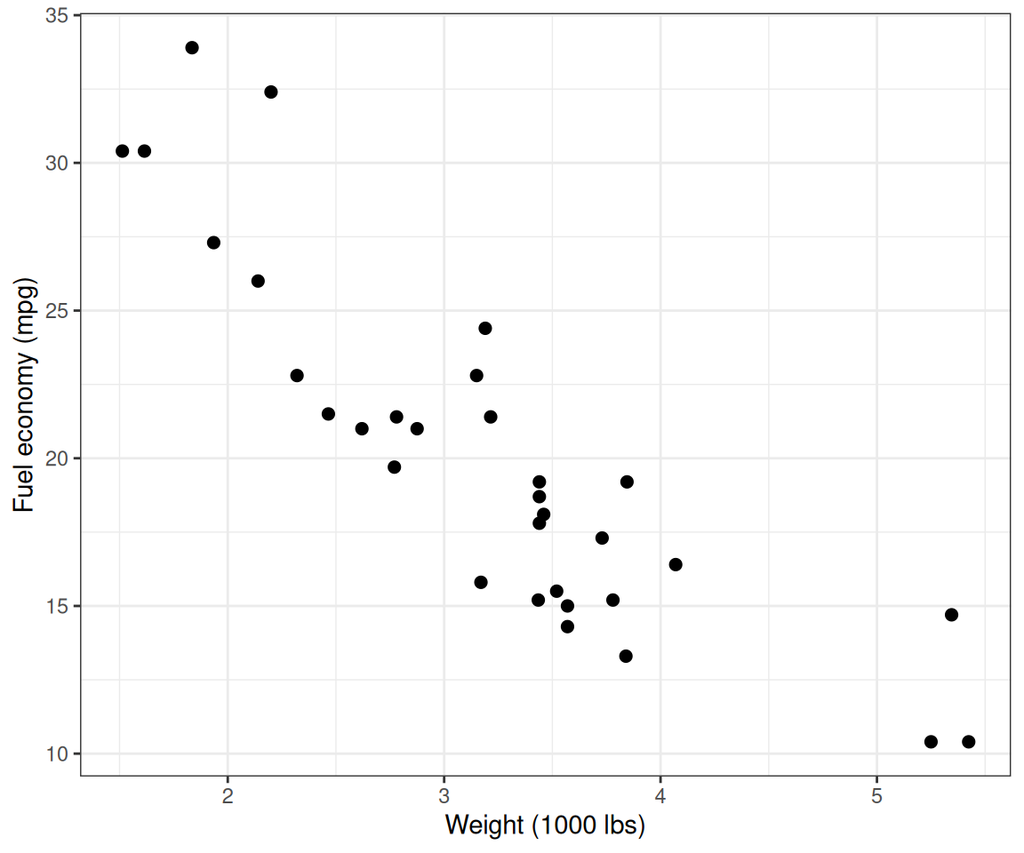

Fuel economy as a function of vehicle weight in mtcars. Each point is one car; the x-axis shows weight in 1000 lbs and the y-axis shows miles per gallon.

**TipWhat this shows**

Each point is one of the **32** cars; mean fuel economy is **20.1 mpg**, and heavier cars are clearly less efficient. This green box is an optional annotation beside the plot — the figure’s own caption sits underneath as usual.

**Nested**

**Table**

| mpg | cyl | disp | hp | drat | wt |
| --- | --- | --- | --- | --- | --- |
| 21 | 6 | 160 | 110 | 3.9 | 2.62 |
| 21 | 6 | 160 | 110 | 3.9 | 2.875 |
| 22.8 | 4 | 108 | 93 | 3.85 | 2.32 |
| 21.4 | 6 | 258 | 110 | 3.08 | 3.215 |
| 18.7 | 8 | 360 | 175 | 3.15 | 3.44 |
| 18.1 | 6 | 225 | 105 | 2.76 | 3.46 |
| 14.3 | 8 | 360 | 245 | 3.21 | 3.57 |
| 24.4 | 4 | 146.7 | 62 | 3.69 | 3.19 |

**Figure**

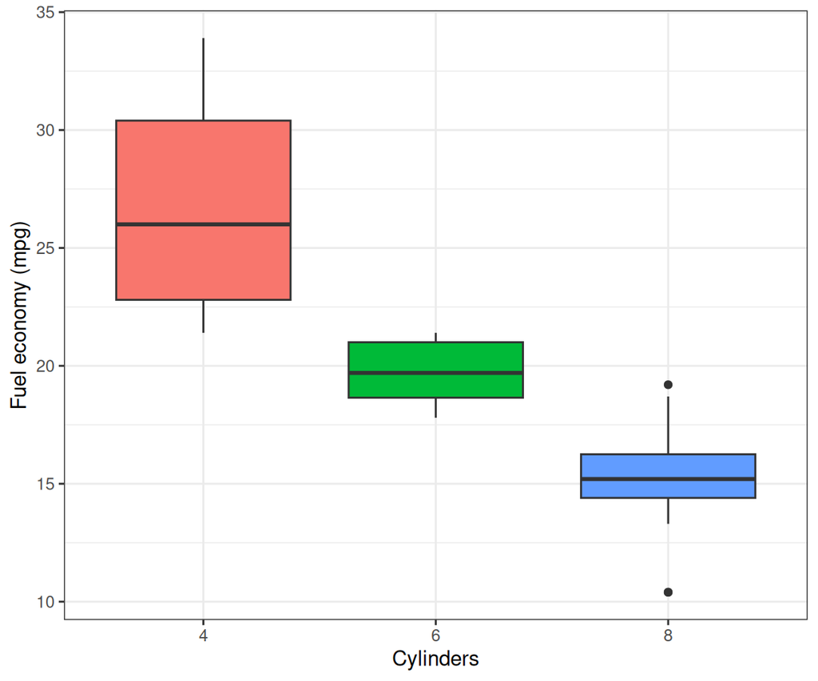

Fuel economy by cylinder count in mtcars. Boxplots summarize miles per gallon for cars grouped by number of cylinders.

**Three-level**

**By dimension**

**Sepal**

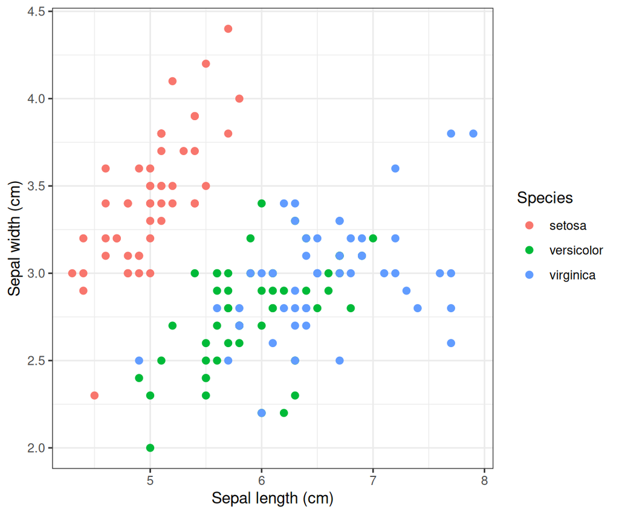

Sepal width as a function of sepal length in iris. Each point is one flower; colour encodes species and both axes are measured in centimetres.

**Petal**

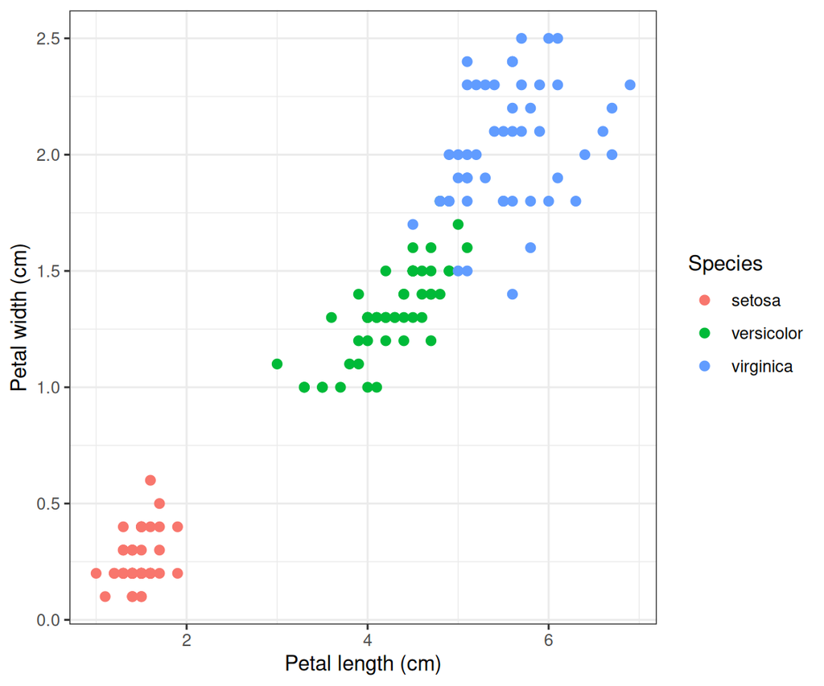

Petal width as a function of petal length in iris. Each point is one flower; colour encodes species and both axes are measured in centimetres.

**Distributions**

**Sepal length**

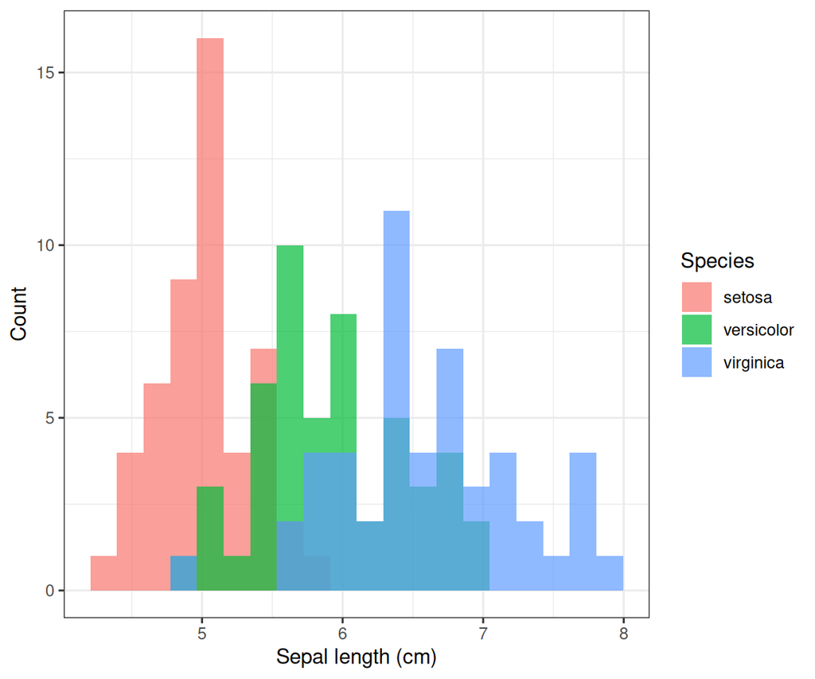

Distribution of sepal length by iris species. Overlaid histograms show flower counts across 20 sepal-length bins in centimetres.

**Petal length**

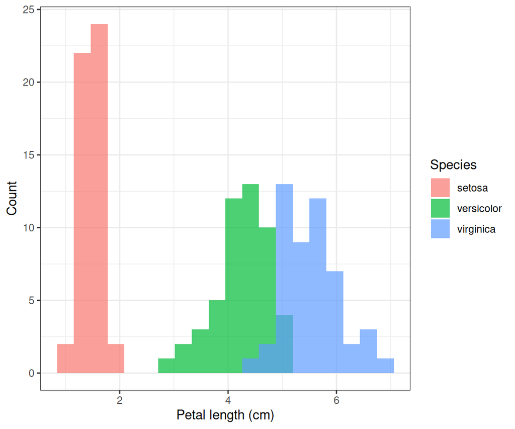

Distribution of petal length by iris species. Overlaid histograms show flower counts across 20 petal-length bins in centimetres.

**Interactive density**

[interactive chart not shown]

Interactive density of sepal length by iris species. Each curve shows the kernel density estimate for one species; hover over the Plotly chart to inspect coordinates.

**Five-level**

**Level 2 · A**

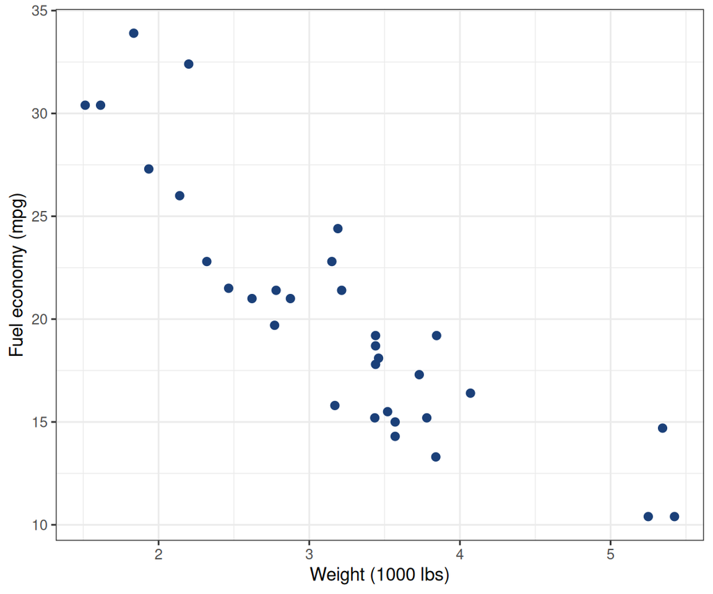

Fuel economy as a function of vehicle weight in mtcars. Each point is one car; the x-axis shows weight in 1000 lbs and the y-axis shows miles per gallon.

**Level 2 · B (go deeper)**

**Level 3 · A**

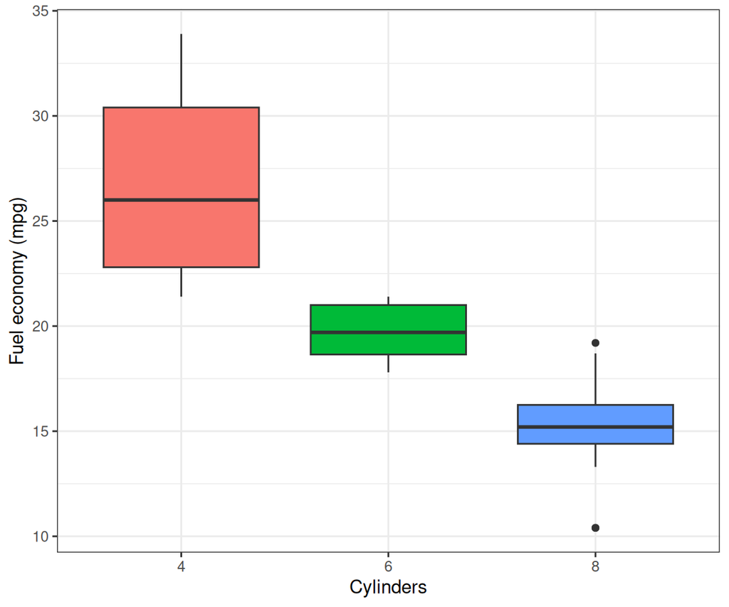

Fuel economy by cylinder count in mtcars. Boxplots summarize miles per gallon for cars grouped by number of cylinders.

**Level 3 · B (go deeper)**

**Level 4 · A**

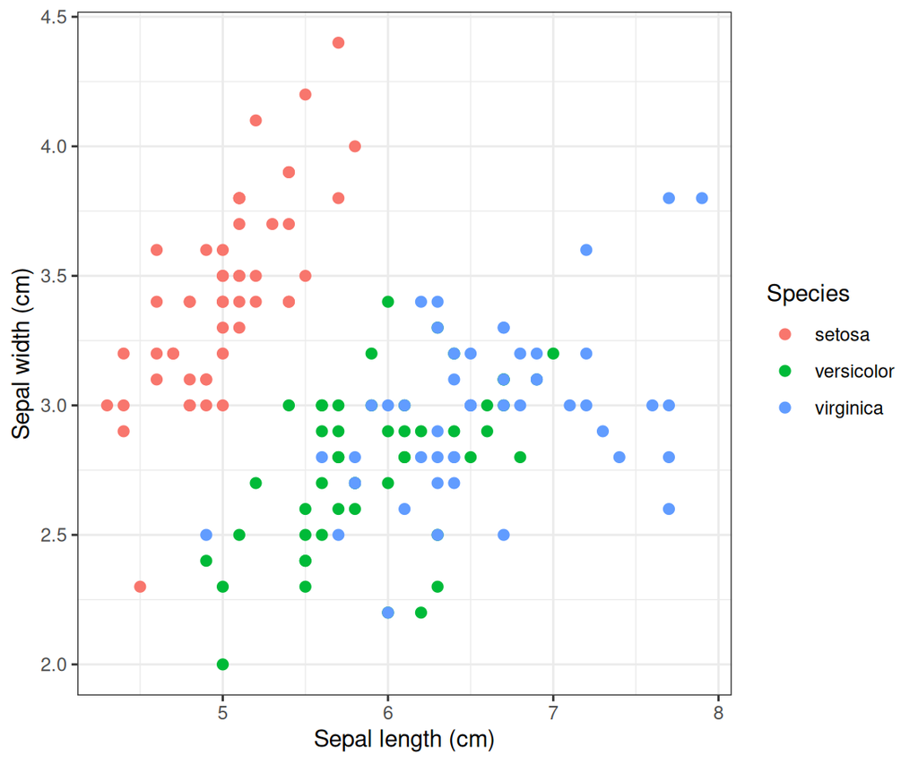

Sepal width as a function of sepal length in iris. Each point is one flower; colour encodes species and both axes are measured in centimetres.

**Level 4 · B (go deeper)**

**Level 5 · A**

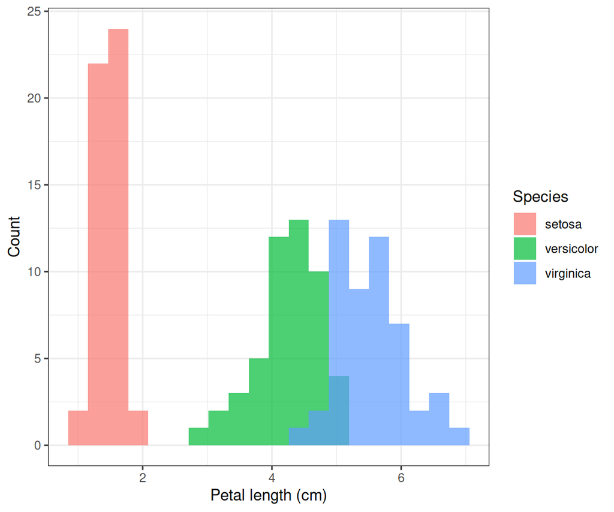

Distribution of petal length by iris species. Overlaid histograms show flower counts across 20 petal-length bins in centimetres.

**Level 5 · B**

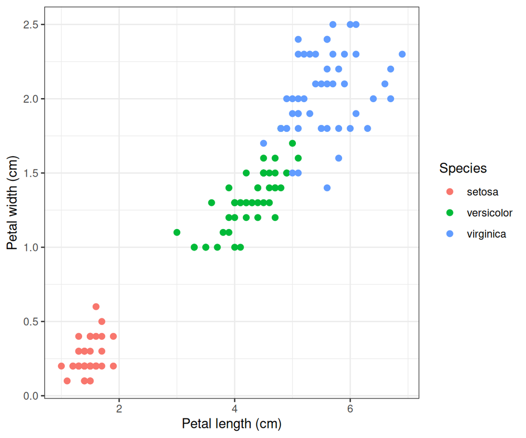

Petal width as a function of petal length in iris. Each point is one flower; colour encodes species and both axes are measured in centimetres.

**Session Info**

**Report provenance**

Provenance for this rendered example report.

| Field | Value |
| --- | --- |
| Project | Example project |
| Order | Example order |
| Workunit | Example workunit |
| Created by | fgczQuartoTemplate example vignette |
| Creation timestamp | 2026-11-02 13:05:28 UTC |
| Qmd source | example-report.qmd |
| Input data reference | datasets::iris and datasets::mtcars (bundled with R) |
| Analysis software | R version 4.6.2 (2026-10-29) |
| Model | Not applicable (layout demonstration) |
| Report package | fgczQuartoTemplate 0.2.0 |

**R session info**

## Download

- Qmd source
- HTML page

Select all plots

Plots download at the resolution embedded in the report (its fig-dpi). Interactive (plotly) charts aren't listed — export those from their own toolbar.